# RedWineQuality

#### quality/alcohol and sulphates by each volatile.acidity group

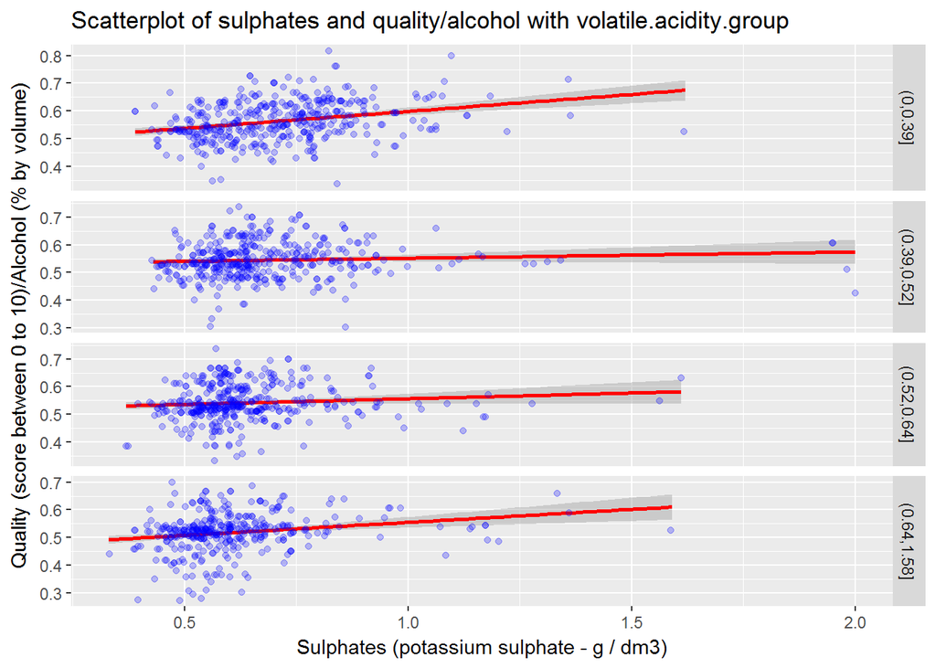

The facet grid above shows the relationship between quality/alcohol with sulphates at different groups of volatile.acidity. It shows that at all levels of volatile.acidity, there is a positive linear trend between sulphates and quality/alcohol. I also noticed the outliers in 2nd quartile of the volatile.acidity group. Removing these outliers show that the 1st quartile of the volatile.acidity group has the highest linear slope (0.1225) between sulphates and quality/alcohol.

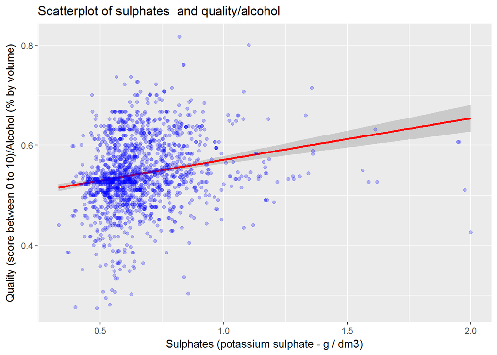

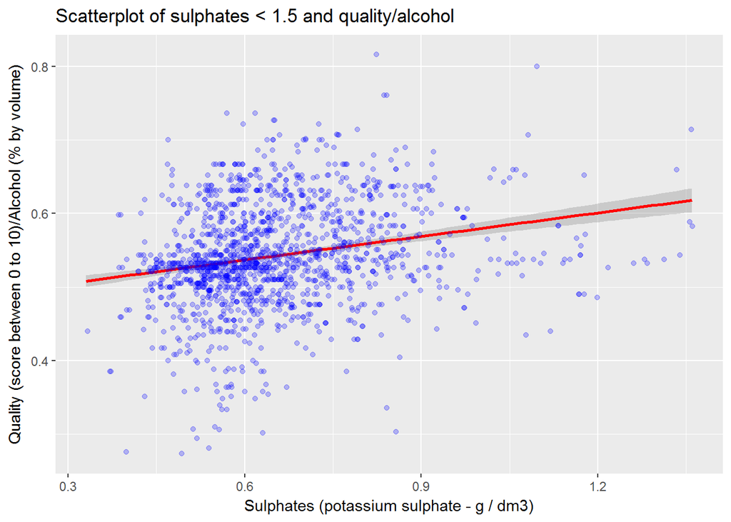

The following scatterplots tweak and create new variables to better model the relationship with quality/alcohol.

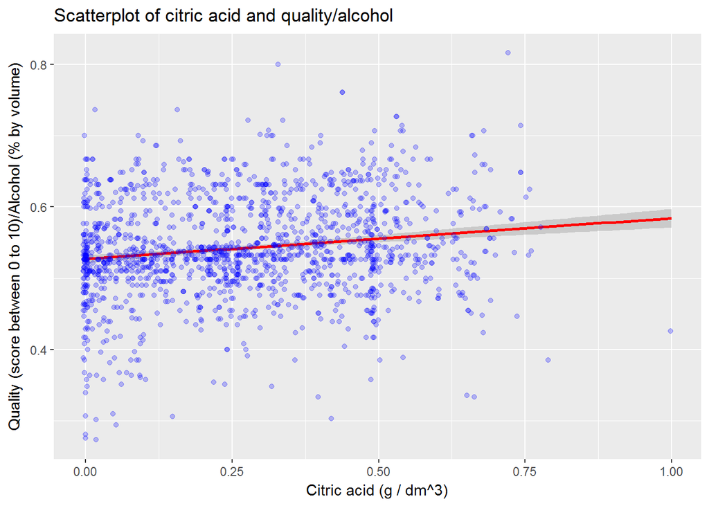

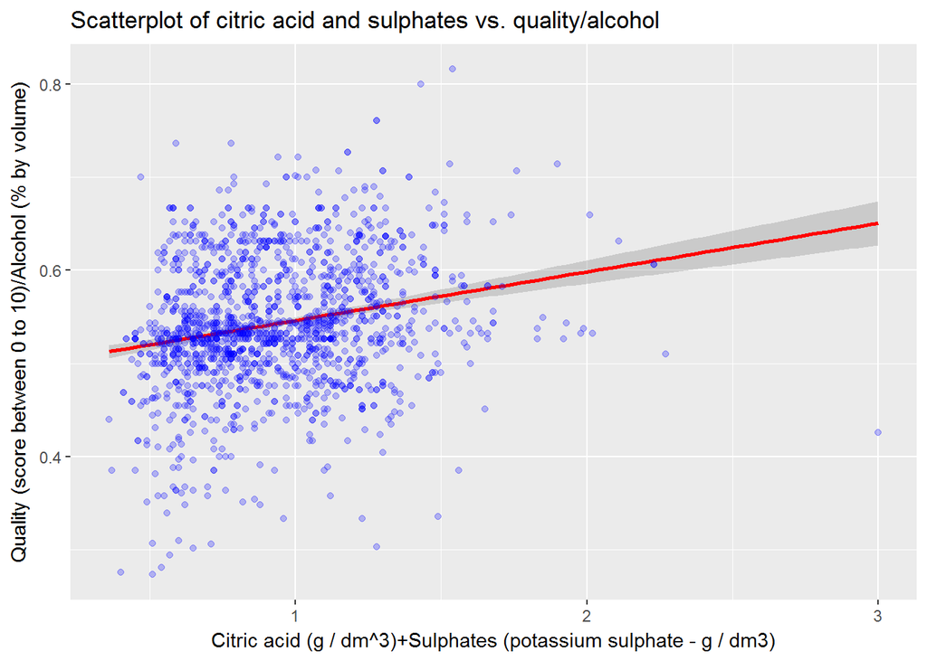

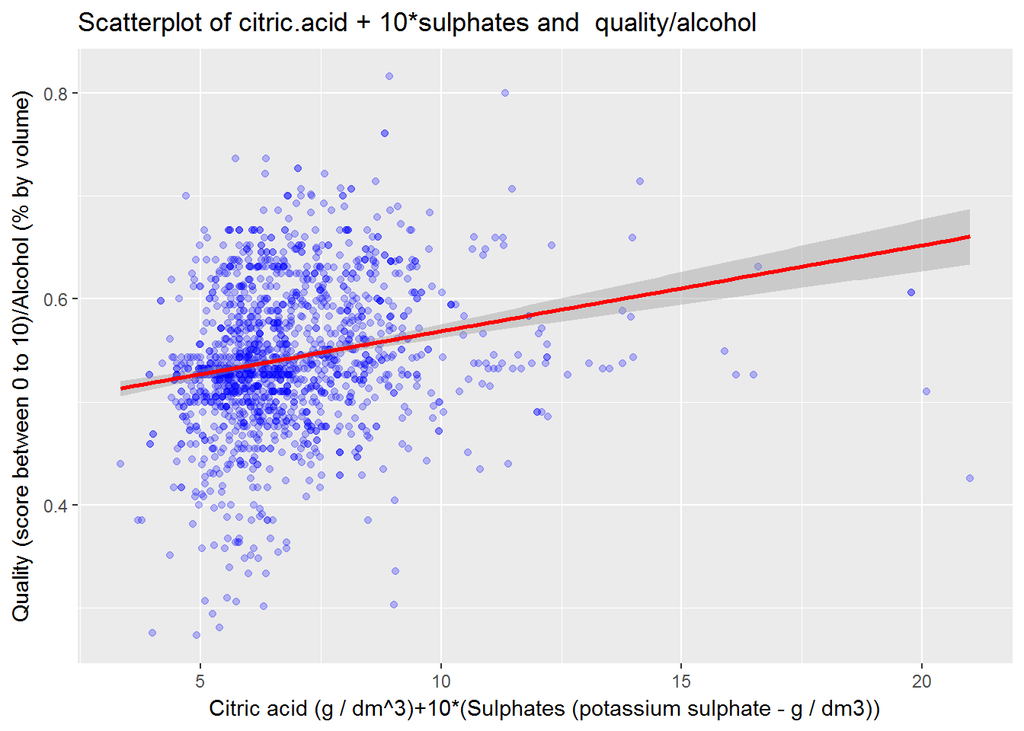

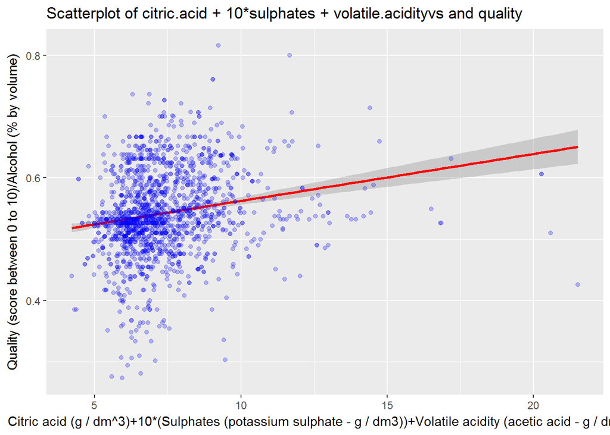

```
##
## Call:
## lm(formula = quality ~ alcohol, data = wineQalityReds)
##
## Residuals:
##     Min      1Q  Median      3Q     Max
## -2.8442 -0.4112 -0.1690  0.5166  2.5888
##
## Coefficients:
##             Estimate Std. Error t value Pr(>|t|)
## (Intercept)  1.87497    0.17471   10.73   <2e-16 ***
## alcohol      0.36084    0.01668   21.64   <2e-16 ***
## ---
## Signif. codes:  0 '***' 0.001 '**' 0.01 '*' 0.05 '.' 0.1 ' ' 1
##
## Residual standard error: 0.7104 on 1597 degrees of freedom
## Multiple R-squared:  0.2267, Adjusted R-squared:  0.2263
## F-statistic: 468.3 on 1 and 1597 DF,  p-value: < 2.2e-16
```

This linear model explain 22.6 % of variance in the quality of wines

```r
fit5<-lm(fomula =quality~volatile.acidity, data=wineQalityReds)
summary(fit5)
```

```
##
## Call:
## lm(data = wineQalityReds, fomula = quality ~ volatile.acidity)
##
## Residuals:
##      Min       1Q   Median       3Q      Max
## -1063.77  -289.90     5.62   318.17  1015.93
##
## Coefficients:
##                                     Estimate Std. Error t value Pr(>|t|)
## (Intercept)                        4.286e+04  1.368e+04   3.134 0.001754
## fixed.acidity                     -7.597e+01  1.673e+01  -4.541 6.02e-06
## volatile.acidity                  -8.345e+01  1.460e+02  -0.572 0.567622
## citric.acid                       -2.088e+02  1.941e+02  -1.076 0.282091
## residual.sugar                     1.489e+01  9.514e+00   1.565 0.117842
## chlorides                         -3.401e+02  2.734e+02  -1.244 0.213756
## free.sulfur.dioxide                1.230e+01  1.390e+00   8.852  < 2e-16
## total.sulfur.dioxide              -4.706e+00  4.753e-01  -9.900  < 2e-16
## density                           -4.011e+04  1.395e+04  -2.876 0.004086
## pH                                -5.669e+02  1.241e+02  -4.567 5.32e-06
## sulphates                         -3.221e+02  1.235e+02  -2.609 0.009162
## alcohol                            7.154e+01  1.743e+01   4.104 4.26e-05
## quality                           -3.570e+01  1.610e+01  -2.217 0.026737
## sulphates.group(0.55,0.62]         5.927e-01  3.152e+01   0.019 0.985000
## sulphates.group(0.62,0.73]         6.029e+01  3.850e+01   1.566 0.117563
## sulphates.group(0.73,2]            4.309e+01  5.651e+01   0.762 0.445911
## citric.acid.group(0.09,0.26]       9.695e+01  4.116e+01   2.355 0.018625
## citric.acid.group(0.26,0.42]       2.287e+02  6.538e+01   3.498 0.000481
## citric.acid.group(0.42,1]          2.095e+02  9.608e+01   2.181 0.029335
## volatile.acidity.group(0.39,0.52]  1.116e+00  3.629e+01   0.031 0.975472
## volatile.acidity.group(0.52,0.64]  9.731e+01  5.133e+01   1.896 0.058184
## volatile.acidity.group(0.64,1.58]  9.799e+01  7.264e+01   1.349 0.177560
##
## (Intercept)                       **
## fixed.acidity                     ***
## volatile.acidity
## citric.acid
## residual.sugar
## chlorides
## free.sulfur.dioxide               ***
## total.sulfur.dioxide              ***
## density                           **
## pH                                ***
## sulphates                         **
## alcohol                           ***
## quality                           *
## sulphates.group(0.55,0.62]
## sulphates.group(0.62,0.73]
## sulphates.group(0.73,2]
## citric.acid.group(0.09,0.26]      *
## citric.acid.group(0.26,0.42]      ***
## citric.acid.group(0.42,1]         *
## volatile.acidity.group(0.39,0.52]
## volatile.acidity.group(0.52,0.64] .
## volatile.acidity.group(0.64,1.58]
## ---
## Signif. codes:  0 '***' 0.001 '**' 0.01 '*' 0.05 '.' 0.1 ' ' 1
##
## Residual standard error: 408.4 on 1577 degrees of freedom
## Multiple R-squared:  0.2278, Adjusted R-squared:  0.2175
## F-statistic: 22.15 on 21 and 1577 DF,  p-value: < 2.2e-16
```

[output not shown]

## Multivariate Analysis

### Talk about some of the relationships you observed in this part of the investigation. Were there features that strengthened each other in terms of looking at your feature(s) of interest?

Because alcohol was the best indicator in explaining variance in quality of wines, I used other variables to explain quality/alcohol as a dependent variable. Relationships between other variables and quality were largely consistent with their relationships with quality/alcohol.

### Were there any interesting or surprising interactions between features?

In reducing the wide variance between variables and quality/alcohol, multiplying sulphates by 10 had the best results. On other variables, multiplying numbers only widened the variance.

## Final Plots and Summary

### Plot one

#### Boxplots of factor(sulphates.group and quality/alcohol

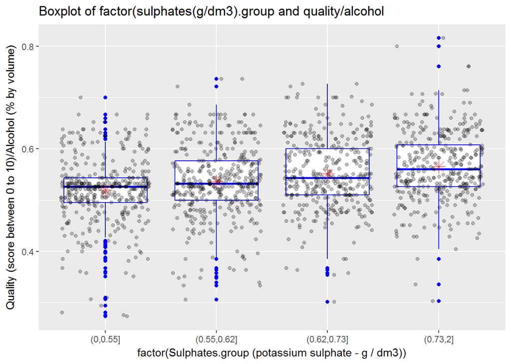

This plot supports other findings of the positive relationship between sulphates and quality. Using this finding with others, I use them later to add sulphates in the linear regression model to predict the quality of wines.

### Plot two

#### Sulphates and quality/alcohol based each group of citric acid

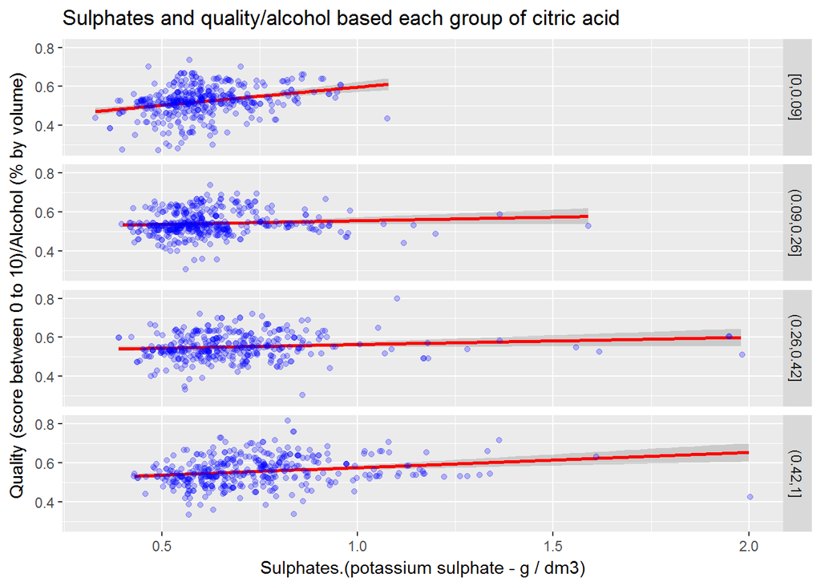

The above scatterplot shows sulphates in the x-axis and quality/alcohol in the y-axis. Each facet represents 1syt through 4th quartiles of citric acid. Running linear regressions previously showed that 1st quartile of citric acid has the highest slope (0.1864).

### Plot three

#### quality/alcohol vs. citric.acid + 10*sulphates

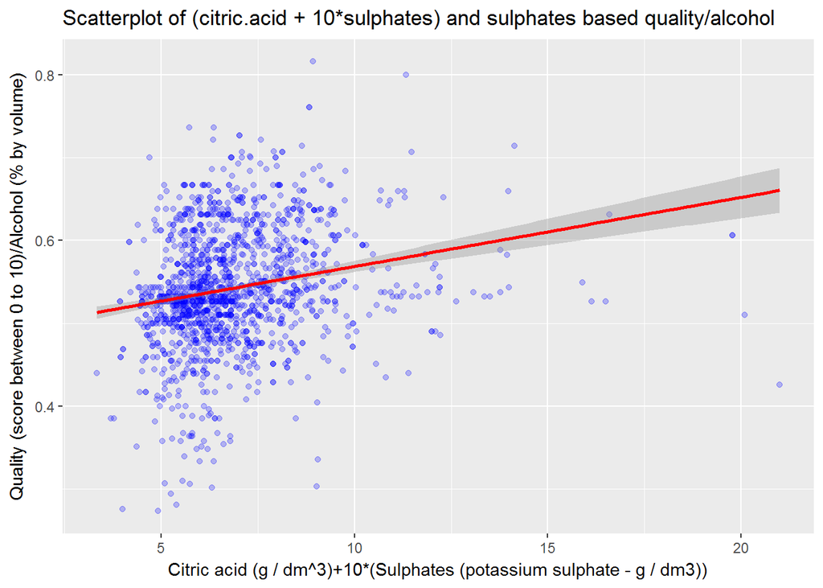

Using quality/alcohol as the dependent variable, this scatterplot reduced the variance with the interaction between citric acid and sulphates. This shows a clear trend that as the interaction between citric acid and sulphates goes up, quality/alcohol goes up.

Multivariate Regression Analysis

```
## Analysis of Variance Table
##
## Response: quality
##                    Df Sum Sq Mean Sq F value    Pr(>F)
## alcohol             1 236.29 236.295  544.56 < 2.2e-16 ***
## sulphates           1  44.98  44.977  103.65 < 2.2e-16 ***
## volatile.acidity    1  68.79  68.789  158.53 < 2.2e-16 ***
## Residuals        1595 692.10   0.434
## ---
## Signif. codes:  0 '***' 0.001 '**' 0.01 '*' 0.05 '.' 0.1 ' ' 1
```

we look ANOVA table, we see this model is meaningfull.

```
##
## Call:
## lm(formula = quality ~ alcohol + sulphates + volatile.acidity,
##     data = wineQalityReds)
##
## Residuals:
##     Min      1Q  Median      3Q     Max
## -2.7186 -0.3820 -0.0641  0.4746  2.1807
##
## Coefficients:
##                  Estimate Std. Error t value Pr(>|t|)
## (Intercept)       2.61083    0.19569  13.342  < 2e-16 ***
## alcohol           0.30922    0.01580  19.566  < 2e-16 ***
## sulphates         0.67903    0.10080   6.737 2.26e-11 ***
## volatile.acidity -1.22140    0.09701 -12.591  < 2e-16 ***
## ---
## Signif. codes:  0 '***' 0.001 '**' 0.01 '*' 0.05 '.' 0.1 ' ' 1
##
## Residual standard error: 0.6587 on 1595 degrees of freedom
## Multiple R-squared:  0.3359, Adjusted R-squared:  0.3346
## F-statistic: 268.9 on 3 and 1595 DF,  p-value: < 2.2e-16
```

## Reflection

The wineQalityRed data set contains information on the chemical properties of a selection of wines.

I tried investigating the effect on quality of wine.I used correlation matrix. But i saw big correlation diffrent variable.This was suprise for me.there is higher correlation between citric.acid, dentisy, ph and fixed.acidity. Also there is higher correlation between citric.acid and ph. On the other hand,there is hig correlation between alcohol,volatile.acidity and quality.I used scatterplots to explore the relationships graphically and also generated a linear model to understand data.

On the final part of the analysis I tried using multivariate plots to investigate if there were interesting combinations of variables that might affect quality. In the end, the produced model explain 34 of the variance in quality. I believe that having this extra information would add more value to the analysis.